# Perform Downstream Analysis

This notebook is for performing downstream analysis of CYCLOPS. It includes running cosinor regression and assessing differential rhythmicity (two ways for both), calling the enrichR API via python, using fgsea in R, running PSEA, outputing files for making KEGG map diagrams, etc.

### Load Packages

This notebook makes use of python via anaconda. Please make sure you install anaconda to proceed:

```r
conda_list()
```

```r
conda_list()[[2]][2] %>%
  use_condaenv(required = TRUE)
print(paste("Using cond env:",conda_list()[[1]][2] ))
```

### Cosinor Regression and Differential Rhythmicity

Run cosinor regression and differential rhythmicity analysis with custom script and with compareRhythms library. I make use of Ensembl and Entrez IDs so I need the following translation dictionaries:

```r
# read in translation dict between gene symbols and other alias
Ensembl_dict = readxl::read_xlsx("scROSMAP_ENSEMBL_dict.xlsx")

#run custom cycling and differential rhythmicity analysis
print("***Running cosinor and differential rhythms analysis***")
run_cycling_and_dr_analysis(path_to_cyclops_ordering, path_to_tmm_file, isCyclingSigCutoff = isCyclingBHQCutoff, percentile = percentile, useBatch = useBatch)
```

### Plotting

With custom regression, I have to remake clock face plots, genes plots, etc.

```r
setwd(path_to_cyclops_ordering)
if (!(dir.exists("downstream_output/plots"))){
  dir.create("downstream_output/plots")
}

#for cycling_in_CTL.csv
plot_clock_face(paste0(path_to_cyclops_ordering, "/downstream_output/plots/CTL_clock_face_plot.png"),"downstream_output/cosinor_results_CTL.csv", mouse_data = mouse_data, BHQ_cutoff = isCyclingBHQCutoff, amp_ratio_cutoff = 0)

setwd(path_to_cyclops_ordering)

#for cycling_in_AD.csv
plot_clock_face(paste0(path_to_cyclops_ordering, "/downstream_output/plots/AD_clock_face_plot.png"),"downstream_output/cosinor_results_AD.csv",mouse_data = mouse_data, BHQ_cutoff = isCyclingBHQCutoff, amp_ratio_cutoff = 0)

#plot cyclops histogram
plot_subject_histogram(path_to_cyclops_ordering, "cond_0")
plot_subject_histogram(path_to_cyclops_ordering, "cond_1")

#Gene Tracings
plot_core_clock_genes(path_to_tmm_file, path_to_cyclops_ordering, useBatch = useBatch, percentile = percentile, split_cond_plots = T)
```

Plot Other Genes

```r
plot_me = c("RPL18","RPS7","RPL22","RPS18","RPL8","RPL10A","RPS13","RPL14","RPS15A","RPS12","RPL36AL","RPL34","RPL30","RPL9","RPL21","RPS28","RPSA","RPL26","RPL27A","FAU","RPS3A","RPL7A","RPL17","RPS27A","RPS16","RPL15","RPLP1","RPL7","RPL10","RPL23A","RPL18A","RPL3","RPL12","RPL39","RPL37A","RPL37","RPS10","RPL13","RPL35A","RPS23","RPL13A","RPL38","RPS29","RPL24","RPL41","RPL35","RPS26","RPS2","RPS9","RPL32","RPL6","RPS21","RPS24","RPS25","RPL36","RPL19","RPS27","RPL29","RPS15","RPS3","RPS5","RPS8","RPL27","RSL24D1","RPS6","RPL11")
tmm = read_csv(path_to_tmm_file, show_col_types = FALSE)
  cyc_pred_file = list.files(path = paste0(path_to_cyclops_ordering, "/Fits/"), pattern = '*Fit_Output_*')
cyc_pred = read_csv(paste(path_to_cyclops_ordering, "Fits", cyc_pred_file[1], sep = '/'), show_col_types = FALSE)
plot_gene_trace(cyc_pred, tmm, plot_me , percentile = percentile, useBatch = useBatch)
```

### EnrichR

Call EnrichR API with python, supplying various lists from cycling and differential rhythm analysis.

```r
path = getwd()
setwd(paste0(path_to_cyclops_ordering, "downstream_output"))
path_no_space = gsub(" ", "\\ ", path, fixed = TRUE)
print(path_no_space)
#create list of filenames from the enrichR_files subfolder
gene_lists = list.files("./enrichR_files/", pattern = "^(CTL_|AD_|diff_mesor)")

#run system command to call python script that uses enrichR API
sapply(gene_lists, function(x){
  system(paste0("python3 ", path_no_space, "/Python_EnrichR_for_AnalysisPipeline.py -g \"enrichR_files/" ,x, "\" -b \"enrichR_files/EnrichR_background.csv\""))})

isCyclingBHQCutoff_str = str_extract(as.character(isCyclingBHQCutoff), "(?<=\\.)\\d+")

setwd("enrichR_files/")
all_DR_gene_lists = list.files( pattern = "^(DR_)")
method2_files = grepl("mthd2", all_DR_gene_lists)
DR_gene_lists_method1 = all_DR_gene_lists[!method2_files]
DR_backgrounds_method1 = paste0("diff_rhythms_CyclingBHQ", isCyclingBHQCutoff_str, "AmpRatio", str_replace(str_extract(DR_gene_lists_method1, pattern = "AR\\d+"), "AR", ""), ".csv")
DR_gene_lists_method2 = all_DR_gene_lists[method2_files]
DR_backgrounds_method2 = paste0("diff_rhythms_method2_CyclingBHQ", isCyclingBHQCutoff_str, "AmpRatio", str_replace(str_extract(DR_gene_lists_method2, pattern = "AR\\d+"), "AR", ""), ".csv")
DR_gene_lists = c(DR_gene_lists_method1, DR_gene_lists_method2)
DR_backgrounds = c(DR_backgrounds_method1, DR_backgrounds_method2)

# repeat with differential gene lists
setwd(paste0(path_to_cyclops_ordering, "downstream_output"))
mapply(function(x, y){
  system(paste0("python3 ", path_no_space, "/Python_EnrichR_for_AnalysisPipeline.py -g \"enrichR_files/" ,x, "\" -b \"",y , "\""))},
  DR_gene_lists,
  DR_backgrounds)

#AD severity
system(paste0("python3 ", path_no_space, "/Python_EnrichR_for_AnalysisPipeline.py -g \"enrichR_files/strong_cogdx_diffs_AR25.csv\" -b \"enrichR_files/AD_cyclers_AR25BHQ05.csv\""))
```

### FGSEA

```r
path = getwd()
setwd(path_to_cyclops_ordering)
if (!(dir.exists("downstream_output/fGSEA"))){
  dir.create("downstream_output/fGSEA")
  dir.create(paste("downstream_output", "fGSEA", "rnk_files", sep = "/"))
  dir.create(paste("downstream_output" , "fGSEA", "fGSEA_results", sep = "/"))
}

isCyclingBHQCutoff_str = str_extract(as.character(isCyclingBHQCutoff), "(?<=\\.)\\d+")

#create rnk files
write_rnks(path_to_cyclops_ordering, isCyclingBHQCutoff_str)

#path of parent folder
setwd(path)

#Pathways, downloaded from MsigDB
pathways <- c(gmtPathways("./MsigDB_gmts_for_GSEA/c2.cp.kegg.v2023.1.Hs.symbols.gmt"), gmtPathways("./MsigDB_gmts_for_GSEA/h.all.v2023.1.Hs.symbols.gmt"))


gene_remapping_dict = read.delim("./MsigDB_gmts_for_GSEA/Human_Gene_Symbol_with_Remapping_MSigDB.v2023.1.Hs.chip", sep = '\t')

setwd(paste(path_to_cyclops_ordering,"downstream_output", "fGSEA", "rnk_files", sep = "/"))

rnk_files = list.files(pattern = ".rnk")


if(!(dir.exists(paste(path_to_cyclops_ordering, "downstream_output","fGSEA","fGSEA_results", sep = "/")))){
  dir.create( paste(path_to_cyclops_ordering,"downstream_output", "fGSEA","fGSEA_results", sep = "/") )
  dir.create( paste(path_to_cyclops_ordering,"downstream_output", "fGSEA","fGSEA_results", "plots",sep = "/"))
}

run_fgsea(rnk_files, gene_remapping_dict, pathways)
```

Run fgsea on sleep related pathways from https://doi.org/10.1152/physiolgenomics.00275.2006

```r
sleep_wake_pathways = gmtPathways("./MsigDB_gmts_for_GSEA/sleep_wake_pathways_w_all_human_aliases_filtered_to_background_genes.gmt")

if(!(dir.exists(paste(path_to_cyclops_ordering, "downstream_output","fGSEA","fGSEA_results_sleep_wake", sep = "/")))){
    dir.create( paste(path_to_cyclops_ordering,"downstream_output", "fGSEA","fGSEA_results_sleep_wake", sep = "/") )
    dir.create( paste(path_to_cyclops_ordering,"downstream_output", "fGSEA","fGSEA_results_sleep_wake", "plots", sep = "/") )
}
setwd(paste(path_to_cyclops_ordering,"downstream_output", "fGSEA", "rnk_files", sep = "/"))

run_fgsea(rnk_files, gene_remapping_dict, sleep_wake_pathways, dir = "fGSEA_results_sleep_wake", max_size = 10000)
```

### Phase Set Enrichment Analysis (PSEA)

```r
path = getwd()
path_no_space = gsub(" ", "\\ ", path, fixed = TRUE)

# List of pathways, downloaded from MsigDB, absolute paths
psea_pathways <- c(paste0(getwd(), "/MsigDB_gmts_for_GSEA/c2.cp.kegg.v2023.1.Hs.symbols.gmt"), paste0(getwd(), "/MsigDB_gmts_for_GSEA/h.all.v2023.1.Hs.symbols.gmt"))

# make sure no spaces when calling cmd
psea_pathways = gsub(" ", "\\ ", psea_pathways, fixed = TRUE)

# change dir into PSEA directory
setwd(paste(path_to_cyclops_ordering,"downstream_output", "PSEA_files",sep = "/"))

#list PSEA input files (generated during cosinor regression/DR step)
psea_files = list.files(pattern = "*.txt")

#Save path to ordering as string for cleaning up call to system
path_to_cyclops_ordering_no_space = gsub(" ", "\\ ", path_to_cyclops_ordering, fixed = TRUE)

#dataframe where rows are arguments to system, I will apply system call across rows
arg_df = expand.grid(psea_files, psea_pathways) %>%
      mutate(out_dirs = paste(str_extract(string = as.character(Var1),     pattern= ".+(?=\\.txt)"), basename(as.character(Var2)) %>% str_extract(pattern= ".+(?=\\.gmt)")%>%
      gsub(pattern = "\\.", replacement = ""), sep = "_") )

#apply system call, calling PSEA jar file, using rows of arg_df as arguments
apply(arg_df, 1, function(a){
    system(paste0("java -jar ", path_no_space, "/PSEA_cmd.jar ",
    paste0(path_to_cyclops_ordering_no_space,
    "/downstream_output/PSEA_files/", a[[1]]), " ", a[[2]]," ",
    paste0(path_to_cyclops_ordering_no_space,
    "/downstream_output/PSEA_files/", a[[3]]), " 5 10000 pdf"))
        })
```

### Transcription Factor Analysis

Now I search for transcription factors associated with my various gene lists, i.e, TF’s associated with genes that lose amplitude in AD, etc.

```r
path = getwd()

#create pscan dir if does not exist:
if(!(dir.exists(paste0(path_to_cyclops_ordering, "downstream_output/pscan")))){
  dir.create(paste0(path_to_cyclops_ordering, "downstream_output/pscan") )
}
setwd(paste0(path_to_cyclops_ordering, "downstream_output"))

#grab gene lists from enrichR files directory
gene_lists = list.files("./enrichR_files/", pattern = "^(CTL_|AD_|DR_)")

#write pscan input
lapply(gene_lists, write_pscan_input)
path_no_space = gsub(" ", "\\ ", path, fixed = TRUE)

setwd("pscan/")
pscan_files = list.files("./pscan_files/", pattern = ".csv$")

sapply(pscan_files, function(x){
  system(paste0("python3 ", path_no_space, "/pscan_requests.py --file pscan_files/" ,x))})

isCyclingBHQCutoff_str = str_extract(as.character(isCyclingBHQCutoff), "(?<=\\.)\\d+")

if(exists("deseq_de_filename")){
  setwd("pscan_results")
  pscan_result_files = list.files(pattern = ".csv$")
  print("Searching cycling and DR results for pscan TF")
  sapply(pscan_result_files, augment_tf_file, deseq_de_filename, isCyclingBHQCutoff_str)
  setwd(paste0(path_to_cyclops_ordering, "downstream_output/enrichR_results"))
  directories = list.files()
  enrichR_TF_paths <- lapply(directories, function(dir) list.files(dir, full.names = TRUE, recursive = TRUE, pattern = ".*TRANSFACandJASPARPWMs_BCKGRND.*\\.csv|.*TranscriptionFactorPPIs_BCKGRND.*\\.csv"))
  enrichR_TF_paths = flatten(enrichR_TF_paths) %>% paste0("./", .)
  sapply(enrichR_TF_paths, augment_tf_file, deseq_de_filename,     isCyclingBHQCutoff_str)

}
```

### Write KEGG Files

Write Files for Kegg Pathway Diagrams

```r
entrez_dict = readxl::read_excel("scROSMAP_ENSEMBL_ENTREZ_dict.xlsx")

setwd(path_to_cyclops_ordering)
isCyclingBHQCutoff_str = str_extract(as.character(isCyclingBHQCutoff), "(?<=\\.)\\d+")

if (!(dir.exists("downstream_output/KEGG_map_diagrams"))){
  dir.create("downstream_output/KEGG_map_diagrams")
}
write_kegg_map_files(paste0("downstream_output/diff_rhythms_CyclingBHQ", isCyclingBHQCutoff_str, "AmpRatio25.csv"),"Log_AD_CTL_ampRatio", trans_dict = entrez_dict,BHQ_cutoff = 0.2)
```

### Metabolon

```r
if (!(dir.exists(paste0(path_to_cyclops_ordering, "/downstream_output/metabolon")))){
  dir.create(paste0(path_to_cyclops_ordering, "/downstream_output/metabolon"))
}

order_metabolon(metabolon_filename, metabolon_datakey, path_to_rosmap_clin, path_to_cyclops_ordering)
```

### Proteomics

Make sure you have downloaded **syn32835854**, **syn21266449**, and **syn51389605**. You can download programmatically with python or R synapse client. Make sure you specify the path to those downloads with *proteiomics_file_path.*

```r
proteiomics_file_path = "~/Box Sync/Henry_stuff/AD_project/scROSMAP/Proteomics/SynapseDownloads/"
# tmt_filename = "2b.unlogged_relative_abundance-ROSMAP610.R1+R2-2xTAMPORcorrected.csv" #syn51389605
tmt_filename = "3.Regressed(age.sex.PMI-noDxProtect)_cleanDat-7814x610-ROSMAP610_R1+R2(Uniprot2019multiconsensus).csv"

#make sure you have downloaded syn32835854,  syn21266449, and syn51389605
if (!(dir.exists(paste0(path_to_cyclops_ordering, "/downstream_output/proteomics")))){
  dir.create(paste0(path_to_cyclops_ordering, "/downstream_output/proteomics"))
}

order_prot(proteiomics_file_path, tmt_filename, path_to_rosmap_clin, path_to_cyclops_ordering)
```

Plot Other Proteins

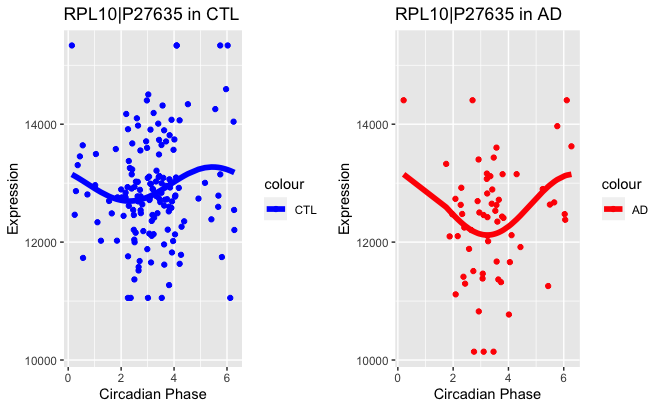

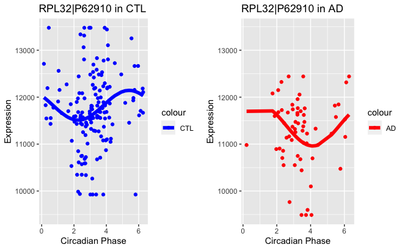

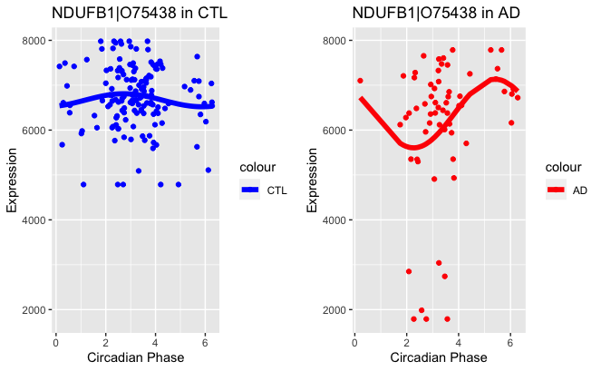

```r
plot_prot(proteiomics_file_path, tmt_filename, path_to_rosmap_clin, path_to_cyclops_ordering, c("RPL10|P27635", "RPL32|P62910", "NDUFB1|O75438"), percentile = percentile)
```

GSEA on proteomics

```r
setwd(path_to_cyclops_ordering)
if (!(dir.exists("downstream_output/proteomics/fGSEA"))){
  dir.create("downstream_output/proteomics/fGSEA")
  dir.create("downstream_output/proteomics/fGSEA/rnk_files")
  dir.create("downstream_output/proteomics/fGSEA/fGSEA_results")
}
```